# tind

**Tinder is one of the most popular dating applications. Even I have used it in my loneliness during freshman year of university. But I noticed a lot of mixed feelings surrounding the app among my fellow classmates. So I thought, "how many people actually see Tinder in a positive light?" To check that and whether Tinder actually helps people we can analyze the sentiments of Tinder's Google Play Store reviews. Although it weill only be Android user reviews being looked at, that should still be a significant number of people. My personaly theory is that the reviews will be neutral on average, but that's more of a hunch; anyways, I'll get started!**

**First, I will import the necessary Python libraries:**

```python
import pandas as pd
import numpy as np
import matplotlib.pyplot as plt
from nltk.sentiment.vader import SentimentIntensityAnalyzer
from wordcloud import WordCloud, STOPWORDS, ImageColorGenerator
import nltk
import re
from nltk.corpus import stopwords
import string
```

**The dataset I am using for the task of Tinder reviews sentiment analysis is downloaded from Kaggle. It was collected from Tinder reviews on the Google Play store. Let's load it!**

**kaggle dataset: https://www.kaggle.com/datasets/shivkumarganesh/tinder-google-play-store-review**

```python
#Load and examine dataset with .head() and it's columns with info
data = pd.read_csv("tinder_google_play_reviews.csv")
print(data.head(), '\n')
print(data.info())
```

```
                                            reviewId      userName  \
0  gp:AOqpTOF5m-nY12XsKXO0IG-ZQtyvmjwKEp43ILLrhBS...    Kreg Smith
1  gp:AOqpTOFMaTJ6Mj-6hrp6ZI9gU5fzeVZQA9LugbFe1xR...          R.W.
2  gp:AOqpTOGtOLC4xZzUlNT8t1ykvQHfOuhW7oJ0MScukLj...  Benjo cantor
3  gp:AOqpTOGcid22sko0XyvhV1kSpbdKUzx5QlSIi5L1Ovc...   Chris Plata
4  gp:AOqpTOGzA20eNWEOUM8edTHGQfd6OU7Qy48JpUcBT-x...    Dave Midas

                                           userImage  \
0  https://play-lh.googleusercontent.com/a/AATXAJ...
1  https://play-lh.googleusercontent.com/a-/AOh14...
2  https://play-lh.googleusercontent.com/a/AATXAJ...
3  https://play-lh.googleusercontent.com/a/AATXAJ...
4  https://play-lh.googleusercontent.com/a-/AOh14...

                                             content  score  thumbsUpCount  \
0  Got banned for life don't know why they won't ...      1              0
1  I don't know why I was banned .. But I m not a...      1              0
2                  All gays even if your straight🤦🤦🤦      1              0
3  You have to pay so much to even be seen on thi...      1              0
4  I do not understand how so many people use thi...      2              0

  reviewCreatedVersion                   at replyContent repliedAt
0               13.6.1  2022-05-21 04:10:44          NaN       NaN
1                  NaN  2022-05-21 04:08:24          NaN       NaN
2               13.6.1  2022-05-21 04:00:10          NaN       NaN
3                  NaN  2022-05-21 03:47:58          NaN       NaN
4               13.6.1  2022-05-21 03:47:51          NaN       NaN

<class 'pandas.core.frame.DataFrame'>
RangeIndex: 537910 entries, 0 to 537909
Data columns (total 10 columns):
 #   Column                Non-Null Count   Dtype
---  ------                --------------   -----
 0   reviewId              537910 non-null  object
 1   userName              537905 non-null  object
 2   userImage             537910 non-null  object
 3   content               536568 non-null  object
 4   score                 537910 non-null  int64
 5   thumbsUpCount         537910 non-null  int64
 6   reviewCreatedVersion  428516 non-null  object
 7   at                    537910 non-null  object
 8   replyContent          47592 non-null   object
 9   repliedAt             47592 non-null   object
dtypes: int64(2), object(8)
memory usage: 41.0+ MB
None
```

**As we can this data set is massive with 10 columns and over half a million observations but we will be mainly focusing on the 'content' and 'score' columnsso it's not gonna be that bad**

```python
#nltk.download('stopwords') #this line is commented out as it causes slowdowns on my end after intial running and unzipping of the stowords zip file.
stemmer = nltk.SnowballStemmer("english")
stopword=set(stopwords.words("english"))
```

**A stop word is a commonly used word (such as “the”, “a”, “an”, “in”) and what was downloaded above will be a source of words that will help our clean function to... well, clean... below**

```python
def clean(text):
    text = str(text).lower()
    text = re.sub('\[.*?\]', '', text)
    text = re.sub('https?://\S+|www\.\S+', '', text)
    text = re.sub('<.*?>+', '', text)
    text = re.sub('[%s]' % re.escape(string.punctuation), '', text)
    text = re.sub('\n', '', text)
    text = re.sub('\w*\d\w*', '', text)
    text = [word for word in text.split(' ') if word not in stopword] # checks for stopwords
    text=" ".join(text)
    text = [stemmer.stem(word) for word in text.split(' ')]
    text=" ".join(text)
    return text


data["content"] = data["content"].apply(clean) # uses the clean function on the content column
```

**Now that the data is clean, let’s take a looksie at the kind of words people use in the Tinder reviews with a wordcloud!**

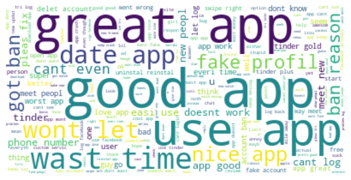

```python
text = " ".join(i for i in data.content) #takes 1.5 minutes on my local machine :(
stopwords = set(STOPWORDS)
wordcloud = WordCloud(stopwords=stopwords, background_color="white").generate(text)
plt.figure( figsize=(10,10))
plt.imshow(wordcloud, interpolation='bilinear')
plt.axis("off")
plt.show()
```

**Now we'll use Valence Aware Dictionary for Sentiment Reasoning (VADER)'s polarity scores function to calculate, and the *SentimentIntensityAnalyzer()* function takes in a string and returns a dictionary of scores in each of four categories: negative, neutral, positive, compound. The code below only uses the first three of which only.**

```python
#nltk.download('vader_lexicon') #similar to before, commented out after unzipping
sentiments = SentimentIntensityAnalyzer() #takes 3 minutes on my local machine :(
data["Positive"] = [sentiments.polarity_scores(i)["pos"] for i in data["content"]]
data["Negative"] = [sentiments.polarity_scores(i)["neg"] for i in data["content"]]
data["Neutral"] = [sentiments.polarity_scores(i)["neu"] for i in data["content"]]
d1 = data[["content", "Positive", "Negative", "Neutral"]] #creates a new dataframe with our calculated scores columns
print(d1.head())
```

```
                                             content  Positive  Negative  \
0  got ban life dont know wont tell help way read...     0.231     0.225
1  dont know ban  allow use tinder henceforth did...     0.371     0.108
2                               gay even straight🤦🤦🤦     0.000     0.000
3  pay much even seen app girl ever talk back bet...     0.229     0.128
4  understand mani peopl use app im mean ugli ive...     0.000     0.225

   Neutral
0    0.544
1    0.521
2    1.000
3    0.642
4    0.775
```

**Now I can do another couple wordclouds similar to a little bit before to display seperatelt the Positive and Negative reviews as a wordcloud. I will start with the Positives:**

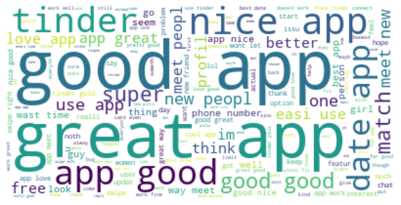

```python
positive =' '.join([i for i in d1['content'][d1['Positive'] > d1["Negative"]]]) #checks if a row's positive score is higher
stopwords = set(STOPWORDS)
wordcloud = WordCloud(stopwords=stopwords, background_color="white").generate(positive)
plt.figure( figsize=(10,10))
plt.imshow(wordcloud, interpolation='bilinear')
plt.axis("off")
plt.show()
```

**Now the Negatives:**

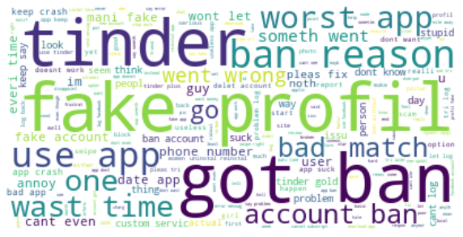

```python
negative =' '.join([i for i in d1['content'][d1['Negative'] > d1["Positive"]]]) #checks if a row's negative score is higher
stopwords = set(STOPWORDS)
wordcloud = WordCloud(stopwords=stopwords, background_color="white").generate(negative)
plt.figure( figsize=(10,10))
plt.imshow(wordcloud, interpolation='bilinear')
plt.axis("off")
plt.show()
```

**Now using the Positive, Negative, and Neutral columns/attributes of the d1 dataframe the I made earlier, we can calculate an over all sentiment score of Tinder with Android users with the function below as well as graph how exactly each column's numbers compare to each other.**

```
Neutral 🙂

Positive:  158277.42200002735
Negative:  59438.14199999961
Neutral:  315592.348999971

Visualized:
```

[figure not shown]

```python
x = sum(d1["Positive"])
y = sum(d1["Negative"])
z = sum(d1["Neutral"])

def sentiment_score(a, b, c): # calculates overall sentiment score
    if (a>b) and (a>c):
        print("Positive 😊 ")
    elif (b>a) and (b>c):
        print("Negative 😠 ")
    else:
        print("Neutral 🙂 ")

sentiment_score(x, y, z)
print("\nPositive: ", x)
print("Negative: ", y)
print("Neutral: ", z, "\n")
print("Visualized: \n")

fig = plt.figure()
ax = fig.add_axes([0,0,1,1])


ex = ['Positive', 'Negative', 'Neutral']
ey = [x,y,z]
plt.bar(ex[0],ey[0],color='g',edgecolor='black')
plt.bar(ex[1],ey[1],color='r',edgecolor='black')
plt.bar(ex[2],ey[2],color='b',edgecolor='black')
plt.xlabel('Sentiment', fontsize=16)
plt.ylabel('Reviews', fontsize=16)
plt.title('Reviews per Sentiment',fontsize=20)

txt="Shows the number of reviews for each \nsentiment. "
props = dict(boxstyle='round', facecolor='w', alpha=0.5)
ax.text(0.025, 0.96, txt, transform=ax.transAxes, fontsize=14,
        verticalalignment='top', bbox=props)

plt.show()
```

**As we can see it is true to our results that the majority of sentiments of each review are Neutral and Positive is only the second highest. But I don't thinkt hat's the truest way to show how people feel. I think we should take into consideration the Google Play review scores as well as the total sentiments. Because I think that would give us a better picture of the overall opinion**

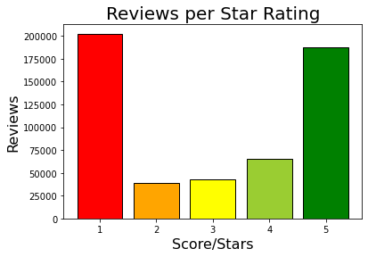

```
But the total average star rating is:  2.996
```

```python
d2 = data['score'].value_counts().sort_index()
del d2[0] #deletes a zero star review that shouldn't exist


fig2 = plt.figure()
ax2 = fig.add_axes([0,0,2,2])

ex = np.arange(1,6,1).tolist() #creates a list of numbers 1 to 5, reflecting our scores
yax = d2.tolist() #converts to list to use for ploting
avgscore = (yax[0] + yax[1]*2 + yax[2]*3 + yax[3]*4 + yax[4]*5)/sum(yax)


clr = ['r','orange','yellow','yellowgreen','green']
for i, item in enumerate([0,1,2,3,4]):
    plt.bar(ex[i],yax[i],color=clr[i],edgecolor='black')
plt.xlabel('Score/Stars', fontsize=16)
plt.ylabel('Reviews', fontsize=16)
plt.title('Reviews per Star Rating',fontsize=20)
plt.show()

print('But the total average star rating is: ', round(avgscore,3))
```

**Now these score/star ratings on first glance show us something a little different than the sentiment score! But I believe this graph to be less correct; why? Because this graph only takes into account what people feel they would rate the app rather than what their words say. The content of their reviews offer much more insight than what they feel the app is graded. The graph is also very misleading with the 1 star rating being the highest but that wouldn't consider the other reviews' weights. However, I do feel there is something to be said as to why the overall sentiment is Neutral just by looking at the star ratings. If you calculate the average of the star ratings, you can see that it pretty much averages out to be around 2.996 (just from looking at the 1 and 5 star ratings averaged out alone), which is a very neutral 3 star rating. Which lines up with the Sentiment Score!**

**My conclusion is that I'm not done digging and I think I should restructure my investigation. However, by what I have written here so far, I can say that the average sentiment towards Tinder by Android users, is in total a Neutral one. I can imagine some being asked randomly on the street: "Hey, how do you feel about that dating app Tidner?" To which a good number of people, including myself and many my friends, would say: "It exists" or "meh"**